# Example of feature selection and model training for EvalDNA

This document provides an example of how to select features (quality metrics) for a model that can estimate genome assembly quality. It then describes how to train and test a random forest model that uses the selected features and can be used by EvalDNA to estimate assembly quality scores.

The first step is to install and load the required libraries.

```r
install.packages("ggplot2", repos="http://cran.r-project.org", dependencies = TRUE)
install.packages("psych", repos="http://cran.r-project.org", dependencies = TRUE)
install.packages("corrplot", repos="http://cran.r-project.org", dependencies = TRUE)
install.packages("Hmisc", repos="http://cran.r-project.org",dependencies = TRUE)
install.packages("praznik", repos="http://cran.r-project.org", dependencies = TRUE)
install.packages("leaps", repos="http://cran.r-project.org", dependencies = TRUE)
install.packages("caret", repos="http://cran.r-project.org",dependencies = TRUE)
install.packages("randomForestSRC", repos="http://cran.r-project.org", dependencies = TRUE)
install.packages("randomForest", repos="http://cran.r-project.org", dependencies = TRUE)
library(leaps)
library(caret)
library(ggplot2)
library(psych)
library(Hmisc)
library(praznik)
library(corrplot)
library(randomForestSRC)
library(randomForest)
```

Then, we set the working directory and read in the training data. The training data needs to be in comma separated value (CSV) format. Each row in this data should be a set quality metrics for an assembly, which are calculated by the metric calculation part of the EvalDNA pipeline, and a target assembly score value, which is calculated by the score4evalDNA.sh script (provided on the EvalDNA GitHub page).

```r
setwd("D:/maddy/Documents/EvalDNA_model_example")
data <- read.csv("Additional_File_2.csv", header=TRUE)
```

Next, we set the seed and shuffle the data. Setting the seed allows us to repeat the same shuffling each time.

```r
set.seed(11)

n <- nrow(data)
shuffled_data <- data[sample(n),]
```

The following code calculates summary statistics for each of the quality metrics in the data file and displays the histograms for each one.

```r
summary(shuffled_data)
```

```
##     normN50            gap_perc       norm_contig_number     links
##  Min.   :  0.7376   Min.   : 0.0000   Min.   :0.004016   Min.   :0.05792
##  1st Qu.: 12.1044   1st Qu.: 0.7072   1st Qu.:0.034342   1st Qu.:0.19318
##  Median : 22.7710   Median : 4.0427   Median :0.189230   Median :0.48375
##  Mean   : 40.1566   Mean   : 5.4291   Mean   :0.507672   Mean   :0.53047
##  3rd Qu.: 67.1178   3rd Qu.: 7.5674   3rd Qu.:0.285655   3rd Qu.:0.63704
##  Max.   :100.0000   Max.   :43.3413   Max.   :8.038655   Max.   :3.01904
##
##   coll_repeat           clip          low_read_cov      prop_pair_perc
##  Min.   : 0.0173   Min.   :0.01161   Min.   : 0.00084   Min.   : 9.47
##  1st Qu.: 1.0535   1st Qu.:0.02490   1st Qu.: 0.01985   1st Qu.:17.61
##  Median : 1.9790   Median :0.03197   Median : 0.08283   Median :25.72
##  Mean   : 2.2254   Mean   :0.08268   Mean   : 0.96900   Mean   :23.40
##  3rd Qu.: 2.9327   3rd Qu.:0.06031   3rd Qu.: 1.31316   3rd Qu.:28.33
##  Max.   :43.8202   Max.   :0.34269   Max.   :34.87049   Max.   :35.76
##
##  error_free_bases FCD_err_in_contig FCD_err_over_gap    low_fc_in_contig
##  Min.   :15.86    Min.   : 0.0000   Min.   :0.0000000   Min.   : 0.02575
##  1st Qu.:51.97    1st Qu.: 0.5761   1st Qu.:0.0006664   1st Qu.: 0.16278
##  Median :55.34    Median : 0.8437   Median :0.0441040   Median : 0.58625
##  Mean   :55.73    Mean   : 1.4808   Mean   :0.1551263   Mean   : 1.60325
##  3rd Qu.:62.02    3rd Qu.: 1.7848   3rd Qu.:0.1312115   3rd Qu.: 2.34538
##  Max.   :68.04    Max.   :23.2215   Max.   :2.9113544   Max.   :15.93899
##
##  low_fc_over_gap     reference.based.quality.score  source     organism
##  Min.   : 0.000000   Min.   :-79.25                gap : 17   human: 69
##  1st Qu.: 0.003492   1st Qu.: 23.81                real:276   mouse:151
##  Median : 0.230065   Median : 51.83                sim :123   rat  :196
##  Mean   : 1.648362   Mean   : 50.55
##  3rd Qu.: 2.172519   3rd Qu.: 80.68
##  Max.   :11.665214   Max.   :100.00
##
##            bld           chr
##  bld2_rat    : 31   18     : 24
##  bld30_mouse : 27   19     : 24
##  bld1_NA19420: 23   16     : 23
##  bld3_NA19420: 23   17     : 23
##  grc38       : 23   8      : 23
##  bld3_rat    : 21   10     : 20
##  (Other)     :268   (Other):279
```

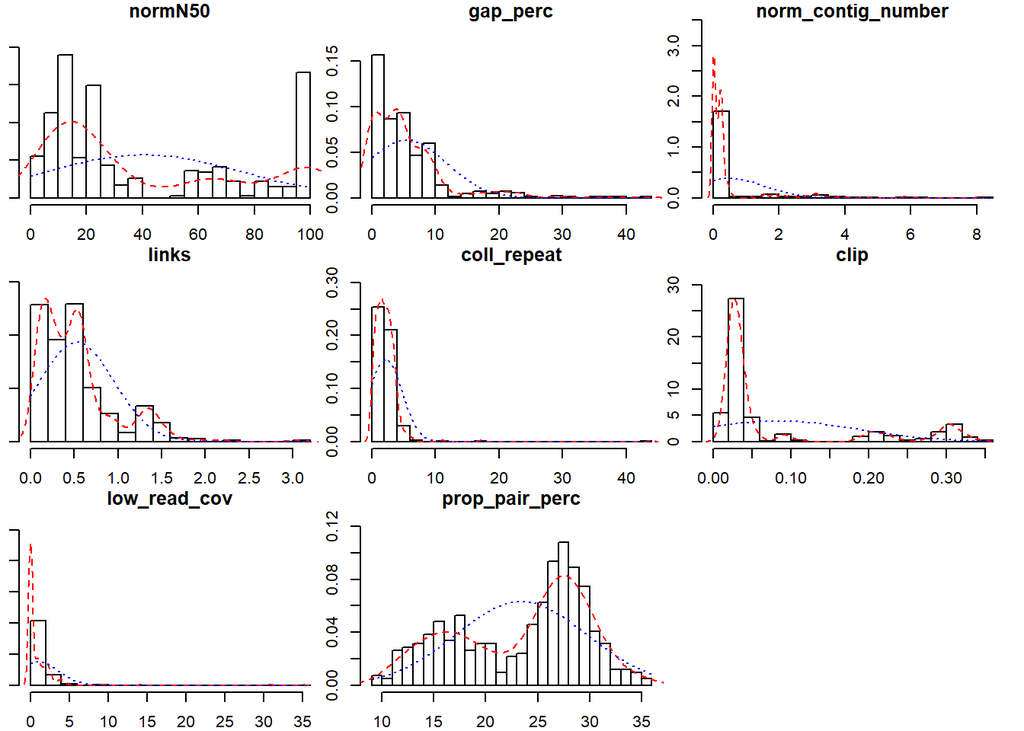

```r
multi.hist(shuffled_data[1:8],dcol=c('red','blue'))
```

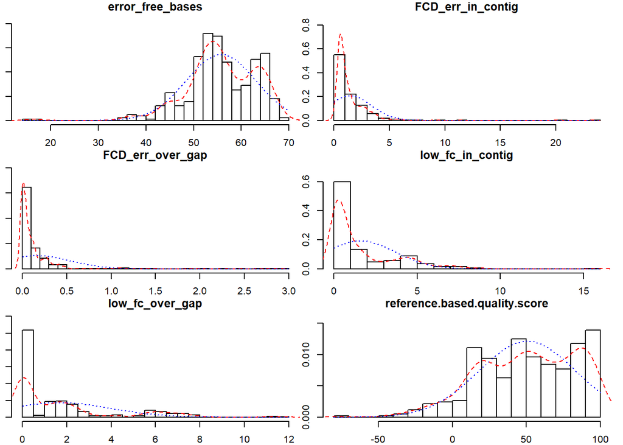

```r
multi.hist(shuffled_data[9:14],dcol=c('red','blue'))
```

Next, we store a version of the shuffled data without the last column which contains the source of the assembly - i.e. real or simulated assembly. Then, we divide the original data into a training subset and testing subset. The code below creates an 80/20 percent train/test split. We also extract the source column for the test data and save it to display in later graphs. We print the number of rows in the training dataset, followed by the number of rows in the testing dataset as a sanity check.

```r
shuffled_data_no_source = shuffled_data[1:14]

train_indices <- 1:round(0.80 * n)
train <- shuffled_data[train_indices, ]

test_indices <- (round(0.80 * n) + 1):n
test <- shuffled_data[test_indices, ]

source_test <- as.factor(test[,15])

nrow(train)
```

```
## [1] 333
```

```r
nrow(test)
```

```
## [1] 83
```

Next, we calculate the pearson correlation value between each metric and the target score. We then create a heatmap displaying the correlation value and p-values among all metrics as well those for the metrics vs. target score.

```r
#Print the pearson correlation value between each metric and the target score
x <- shuffled_data_no_source[1:13]
y <- shuffled_data_no_source[,14]
r <- cor(x, y)
round(r, 4)
```

```
##                       [,1]
## normN50             0.5700
## gap_perc           -0.3004
## norm_contig_number  0.0247
## links              -0.5935
## coll_repeat        -0.0710
## clip               -0.4760
## low_read_cov       -0.4021
## prop_pair_perc      0.2042
## error_free_bases    0.7014
## FCD_err_in_contig  -0.0985
## FCD_err_over_gap   -0.2954
## low_fc_in_contig   -0.5210
## low_fc_over_gap    -0.5789
```

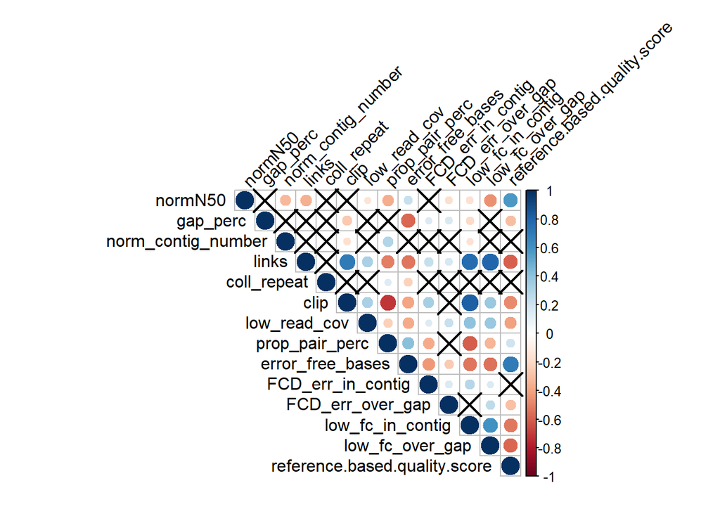

```r
#Pearson correlation and p-values for all features in a heat map
r2 <- rcorr(as.matrix(shuffled_data_no_source[1:14]))
p.mat <- round(r2$P, 4)
layout(1)
corrplot(r2$r, type = "upper", tl.col = "black", tl.srt = 45,sig.level = 0.01,p.mat = p.mat)
```

Now, we remove metrics with a pearson correlation between -0.1 and 0.1 as these only have a very weak linear relationship to the target quality score.

In thise case, norm_contig_number, FCD_err_in_contig, and coll_repeats metrics are removed.

```r
keep <- c("normN50", "gap_perc", "prop_pair_perc", "low_fc_over_gap", "low_fc_in_contig", "FCD_err_over_gap", "links", "clip", "low_read_cov", "error_free_bases" )
metrics_selected = x[keep]
```

Next, we run two feature selection methods: JMIM (minimal joint mutual information maximisation) and Random Forest Importance. JMIM is setup with the parameters to choose the 8 most important features from the remaining 10 features, which are then given to the Random Forest Importance method.

```r
jmim <- JMIM(metrics_selected, y, k = 8, threads = 0)
jmim$score
```

```
## error_free_bases          normN50   prop_pair_perc            links
##        0.5124632        0.9437961        0.8313413        0.7584230
##  low_fc_over_gap         gap_perc             clip low_fc_in_contig
##        0.7070085        0.6274661        0.6010291        0.4382273
```

```r
rf_model_for_feature_selection <- randomForest(reference.based.quality.score ~ normN50 + gap_perc + prop_pair_perc + clip + error_free_bases + links + low_fc_over_gap + low_fc_in_contig, shuffled_data_no_source, mtry=2, ntree=500,importance=TRUE)
rf_model_for_feature_selection$importance
```

```
##                    %IncMSE IncNodePurity
## normN50          301.24733      49134.01
## gap_perc         208.85977      34574.39
## prop_pair_perc    98.53577      16633.55
## clip             200.53741      33085.11
## error_free_bases 328.74294      84659.65
## links            276.86680      80553.76
## low_fc_over_gap  426.07172      77047.70
## low_fc_in_contig 249.77719      65164.05
```

For our data, the importance shows that proper pair percent has low node purity and should be removed. Therefore, we now have 7 quality features remaining. We also do a third feature selection method, called All Subsets Regression, to see if we can narrow down the features further.

```r
best.subset <-regsubsets(reference.based.quality.score ~ normN50 + gap_perc + clip + error_free_bases + links + low_fc_over_gap + low_fc_in_contig,data=shuffled_data_no_source,nbest=4,nvmax=6,really.big=T)
best.subset.summary <- summary(best.subset)
best.subset.by.rss <- which.min(best.subset.summary$rss)
best.subset.summary$which[best.subset.by.rss ,]
```

```
##      (Intercept)          normN50         gap_perc             clip
##             TRUE             TRUE             TRUE             TRUE
## error_free_bases            links  low_fc_over_gap low_fc_in_contig
##             TRUE             TRUE             TRUE            FALSE
```

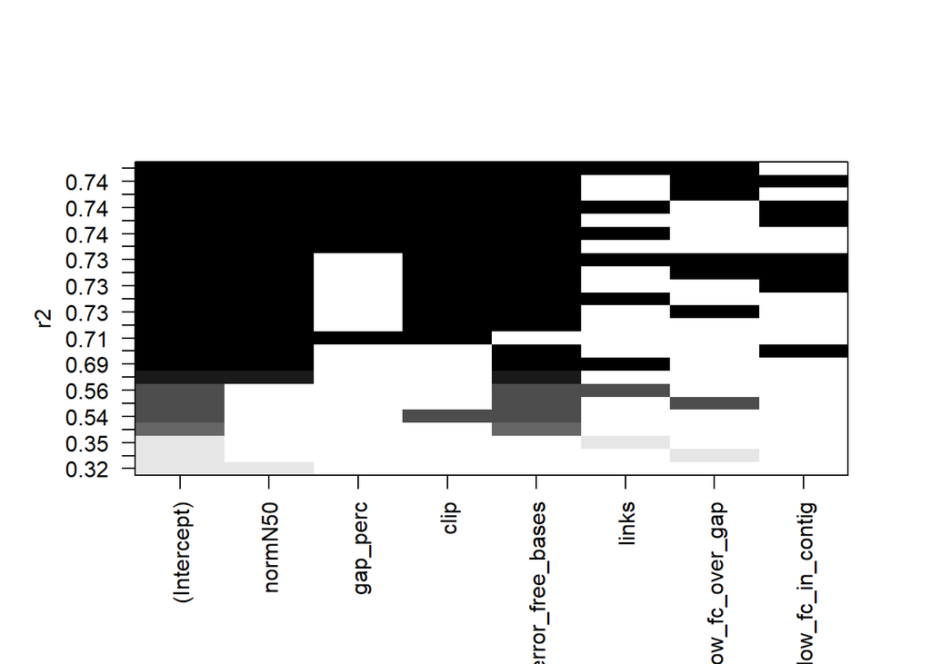

```r
#Plot a table of models showing the features in each model. The models are ordered by R squared.
layout(1)
plot(best.subset, scale="r2")
```

In this case, we decided to remove links from our features even though it was in the first row of the plot above (and in the model given by ‘best.subset.summary$which[best.subset.by.rss ,]’). Removing links did not decrease the r^2 value (shown in the plot above) and other analysis, not shown here, suggested that links caused multicolinearity with other features.

Now we have chosen our features, its time train our random forest model. The below code trains a 500 tree random forest model with 10 fold cross-validation and then applies the new model to the test data we created earlier, printing the R-squared correlation (R^2) and the Root Mean Squared Error (RMSE).

```r
our_model_features = reference.based.quality.score ~ normN50 + gap_perc + clip + error_free_bases + low_fc_over_gap + low_fc_in_contig


control = trainControl(method = "cv", number = 10, verboseIter = TRUE)
fit.rf <- train(our_model_features, data=train, method="rf", metric="RMSE", preProc=c("center", "scale"), trControl=control)
print(fit.rf)
```

```
## Random Forest
##
## 333 samples
##   6 predictor
##
## Pre-processing: centered (6), scaled (6)
## Resampling: Cross-Validated (10 fold)
## Summary of sample sizes: 300, 301, 299, 301, 299, 299, ...
## Resampling results across tuning parameters:
##
##   mtry  RMSE      Rsquared   MAE
##   2     11.65841  0.8833963  8.515760
##   4     11.71395  0.8802949  8.502145
##   6     11.87580  0.8762684  8.473504
##
## RMSE was used to select the optimal model using the smallest value.
## The final value used for the model was mtry = 2.
```

```r
test_pred_rf <- predict(fit.rf, newdata = test)

result <- data.frame(
  RMSE = RMSE(test_pred_rf, test$reference.based.quality.score),
  Rsquare = R2(test_pred_rf, test$reference.based.quality.score)
)
result
```

| RMSE | Rsquare |
| --- | --- |
| 11.13286 | 0.8806144 |

Now, we can plot the results to show how well the model predictions correlate with the actual target scores provided in the data. The plot also provides the R^2 value on the top left.

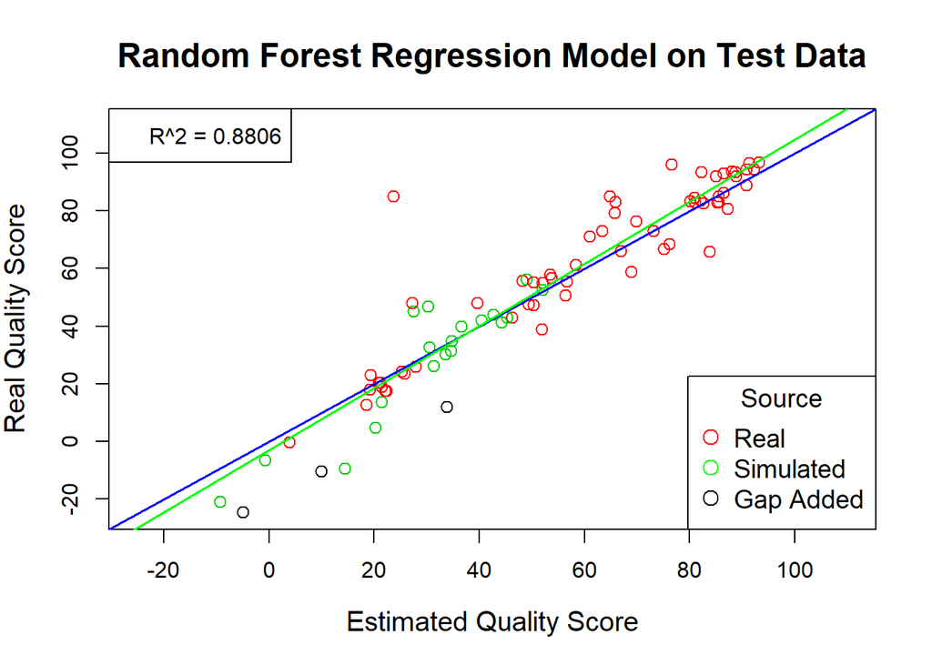

```r
layout(1)
plot(test_pred_rf, test$reference.based.quality.score, main="Random Forest Regression Model on Test Data", cex.main = 1.5, cex = 1.2, pch=1,
     xlab="Estimated Quality Score", ylab="Real Quality Score", col=source_test,xlim=c(-25, 110), ylim=c(-25, 110), pin = c(4,4),cex.lab = 1.25)
abline(0,1,col="blue",lwd=1.75)
abline(lm(test$reference.based.quality.score~test_pred_rf), col="green",lwd=1.5)
legend(x='topleft', pt.cex = 0.8, cex=1, legend=paste('R^2 =',round(round(cor(test_pred_rf, test$reference.based.quality.score),4)*round(cor(test_pred_rf, test$reference.based.quality.score),4),4)))
legend("bottomright", title="Source", cex=1.15, pt.cex = 1.5, legend=c("Real", "Simulated", "Gap Added"), pch=1, col = c("red", "green", "black"))
```

Due to the random nature of the random forest model, there will be some variation in model performance each time the model is trained. Next, we test the model on all the data and display the resulting performance values (R^2 and RMSE).

```r
finalRFModel <- randomForest(our_model_features, shuffled_data_no_source, mtry=2, ntree=500,importance=TRUE)
finalRFModel
```

```
##
## Call:
##  randomForest(formula = our_model_features, data = shuffled_data_no_source,      mtry = 2, ntree = 500, importance = TRUE)
##                Type of random forest: regression
##                      Number of trees: 500
## No. of variables tried at each split: 2
##
##           Mean of squared residuals: 119.5235
##                     % Var explained: 88.92
```

Last of all, we can save the model. The model can now be used in the R scoring script to score a new assembly after it has been submitted to the EvalDNA pipeline for quality metric collection.

```r
saveRDS(finalRFModel, "./our_rf_model.rds")
```